# STAT 327 Homework 4

### Make a graph of the data and model:

- Make a scatterplot of the data, $(x_i, y_i)$.
- Estimate a linear regression model of the form $\hat{y}_i = \hat{\beta}_0 + \hat{\beta}_1 x_i$.
- Display a summary of the model; check that the estimated coefficients are near the true $\beta_0 = 2$ and $\beta_1 = 3$.
- Add a solid black estimated regression line to the plot.
- Add a dashed red true line (y = 2 + 3x) to the plot.
- Add dotted blue 95% pointwise confidence bands that consist, for each prediction $(x_i, \hat{y}_i)$, of a vertical confidence interval around $\hat{y}_i$ centered at $(x_i, \hat{y}_i)$; the formula is $\hat{y}_i \pm t_{n-2, \alpha/2} s_{\hat{y}_i}$, where
  - $\hat{y}_i$ is the predicted $y$ at $x = x_i$ (this is available in the model you calculated)
  - $e_i = y_i - \hat{y}_i$, the $i^{\text{th}}$ residual (this estimate of $\epsilon_i$ is available in the model you calculated)
  - $s = \sqrt{\frac{\sum_{i=1}^n e_i^2}{n - 2}}$ (this is an estimate of $\sigma$)
  - $s_{\hat{y}_i} = s \sqrt{\frac{1}{n} + \frac{(x_i - \bar{x})^2}{\sum_{i=1}^n (x_i - \bar{x})^2}}$
  - $t_{n-2, \alpha/2}$ is the number that cuts off a right-tail area .025 from a Student’s $t$ distribution with $n-2$ degrees of freedom
- Add a legend identifying each of the black, red, and blue lines.

Hint: These calculations might look hard, but they go quickly with R. See Quiz 2’s questions 8-11 for examples of efficiently translating sums into R code.

```r
n = 100
sigma = 4
beta0 = 2
beta1 = 3
x = sort(rnorm(n))
epsi = rnorm(100, 0, 4)
y = beta0 + beta1 * x + epsi
plot(x, y, main = paste0("y ~ x"), xlab = "x", ylab = "y")
model3 = lm(y~x)
model3
```

```
##
## Call:
## lm(formula = y ~ x)
##
## Coefficients:
## (Intercept)            x
##       1.745        3.122
```

```r
summary(model3)
```

```
##
## Call:
## lm(formula = y ~ x)
##
## Residuals:
##      Min       1Q   Median       3Q      Max
## -10.3955  -2.4395   0.2582   2.5999   9.1995
##
## Coefficients:
##             Estimate Std. Error t value Pr(>|t|)
## (Intercept)   1.7446     0.3970   4.395 2.81e-05 ***
## x             3.1219     0.4206   7.422 4.25e-11 ***
## ---
## Signif. codes:  0 '***' 0.001 '**' 0.01 '*' 0.05 '.' 0.1 ' ' 1
##
## Residual standard error: 3.965 on 98 degrees of freedom
## Multiple R-squared:  0.3598, Adjusted R-squared:  0.3533
## F-statistic: 55.08 on 1 and 98 DF,  p-value: 4.248e-11
```

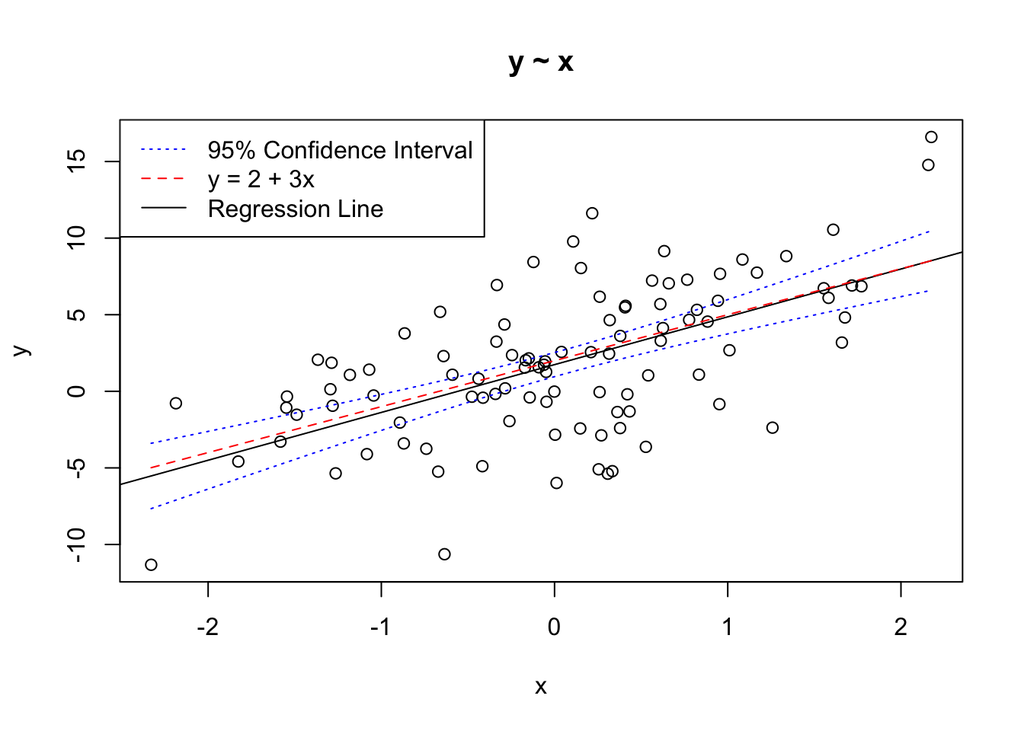

```r
abline(model3)
curve(2 + 3*x , col = "red", lty = "dashed", add = TRUE)

yhat = model3$fitted.values
e = y - yhat
s = sqrt(sum(e^2) / (n - 2))
syhat = s * sqrt(1/n + (x - mean(x))^2/(sum((x - mean(x))^2)))
lower = yhat - syhat * qt(0.975, length(x) - 2)
higher = yhat + syhat * qt(0.975, length(x) - 2)
lines(x, lower, lty = "dotted", col = "blue")
lines(x, higher, lty = "dotted", col = "blue")
legend("topleft", legend = c("95% Confidence Interval","y = 2 + 3x","Regression Line"), col = c("blue", "red", "black"), lty = c("dotted","dashed","solid"))
```